# Glasstire Datahack 2019

Ivan Leung

## Data Exploration

Data are provided by [Glasstire Datahack 2019](https://www.glasstiredatahack.com/).

A sample of the raw data are shown below.

| event_uid | venue_uid | start_date | end_date | venue | coordinates | address | city | zip | url | artist_uid |
| --- | --- | --- | --- | --- | --- | --- | --- | --- | --- | --- |
| 4575 | 10137684 | 2013-05-31 | 2013-09-08 | Houston Center for Contemporary Craft | 29.730715804878,-95.3858012682927 | 4848 Main Street | Houston | 77002 | www.crafthouston.org | 16459675 |
| 13228 | 13371986 | 2012-04-25 | 2012-04-25 | Project Row Houses | 29.7319444081633,-95.3652960612245 | 2521 Holman Street | Houston | 77004 | www.projectrowhouses.org | 3079814 |
| 13228 | 13371986 | 2012-04-25 | 2012-04-25 | Project Row Houses | 29.7319444081633,-95.3652960612245 | 2521 Holman Street | Houston | 77004 | www.projectrowhouses.org | 15368376 |
| 13313 | 13357951 | 2019-03-03 | 2019-04-04 | Watercolor Art Society | 29.7383709,-95.3995419 | 1601 West Alabama Street | Houston | 77006 | www.watercolorhouston.org | NA |
| 13793 | 6249733 | 2016-03-21 | 2016-04-08 | Gallery 220 (HBU) | 29.6980291836735,-95.5152786326531 | 7502 Fondren Road, University Academic Center | Houston | 77074 | NULL | 9052742 |
| 14545 | 2575785 | 2014-09-13 | 2014-09-13 | 14 Pews | 29.8097397906977,-95.3893475116279 | 800 Aurora Street | Houston | 77009 | 14pews.org | 12713617 |

In the data exploration phase, several data issues were seen:

- `start_date` values later than `end_date`
- in `coordinates` column, more than 2 values (separated by `,`) were entered
- inconsistent capitalization of `city` names

These issues were corrected.

Further, time attributes (e.g., year, day of week, season) were created to aid in time series analysis downstream.

A sample of the cleaned data are shown below.

| event_uid | venue | lat | lon | start_dt | event_year | event_mth_lbl | event_wday_lbl | season |
| --- | --- | --- | --- | --- | --- | --- | --- | --- |
| 4575 | Houston Center for Contemporary Craft | 29.730715804878 | -95.3858012682927 | 2013-05-31 | 2013 | May | Fri | spring |
| 13228 | Project Row Houses | 29.7319444081633 | -95.3652960612245 | 2012-04-25 | 2012 | Apr | Wed | spring |
| 13228 | Project Row Houses | 29.7319444081633 | -95.3652960612245 | 2012-04-25 | 2012 | Apr | Wed | spring |
| 13313 | Watercolor Art Society | 29.7383709 | -95.3995419 | 2019-03-03 | 2019 | Mar | Sun | spring |
| 13793 | Gallery 220 (HBU) | 29.6980291836735 | -95.5152786326531 | 2016-03-21 | 2016 | Mar | Mon | spring |
| 14545 | 14 Pews | 29.8097397906977 | -95.3893475116279 | 2014-09-13 | 2014 | Sep | Sat | fall |

## Event Distributions

### When Do Events Happen?

Data filtered to 2018 and top 10 by event count.

[interactive chart not shown]

### Seasonal Variation

As shown, summer seems to be marked by lower event count.

[interactive chart not shown]

### Where Do Event Happens?

[interactive chart not shown]

### Which Artist Are Most Active?

It seems artists come and go, as data show that artists who are among the top host (by event count) no longer have any events in recent years.

[interactive chart not shown]

### Rise and Fall of Artists

Data filtered to artists with ID only.

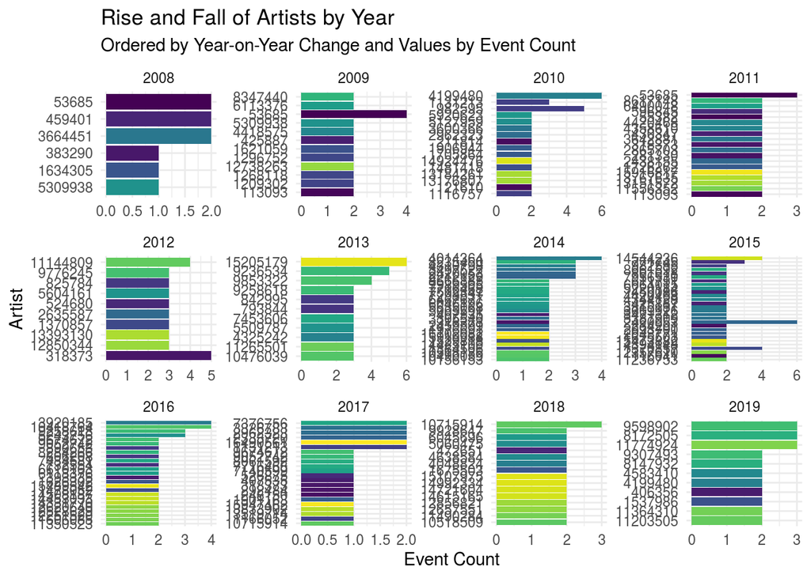

## Event Forecasting

Data filtered to top `zip` codes in 2018, so as to better forecast upcoming events nearing the end of 2019.

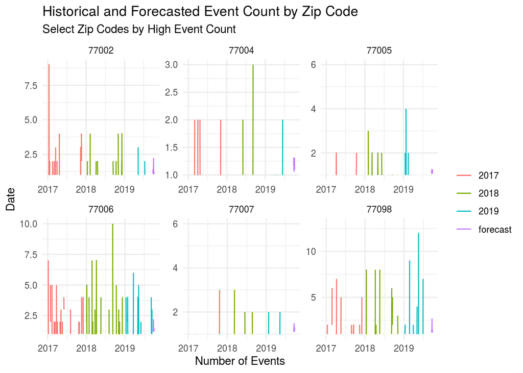

## Integrating Census Data

Census data may help enrich overall data set to uncover more insights about why events are distributed the way they are.

Census data considered include:

- Gini Index (i.e. inequality measure)
- Gender
- Employment
- Median Income
- Computer/Internet Access
- Race
- Education Level
- Household size

Blended data are aggregated on a year level, by `zip`.

### Segmentation

Due to high dimensionality of data, dimension reduction methods (e.g., [*kmeans*](https://en.wikipedia.org/wiki/K-means_clustering) and [*PCA*](https://en.wikipedia.org/wiki/Principal_component_analysis)) are applied, in order to get interpretable insights.

It seems that three clusters yield optimal segregation.

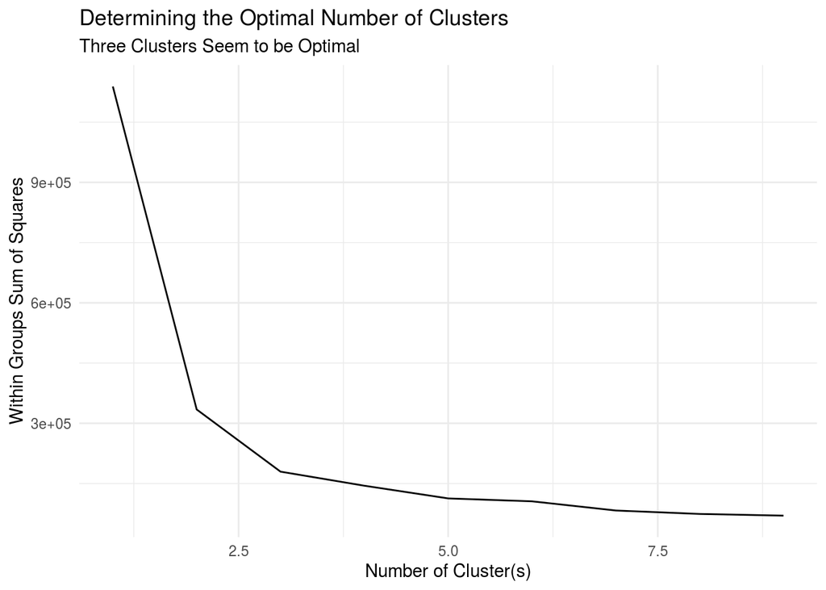

From the plot below, it seems the clustering is performant, at least with respect to event count.

Note that the clustering method is applied on a multi-dimensional basis.

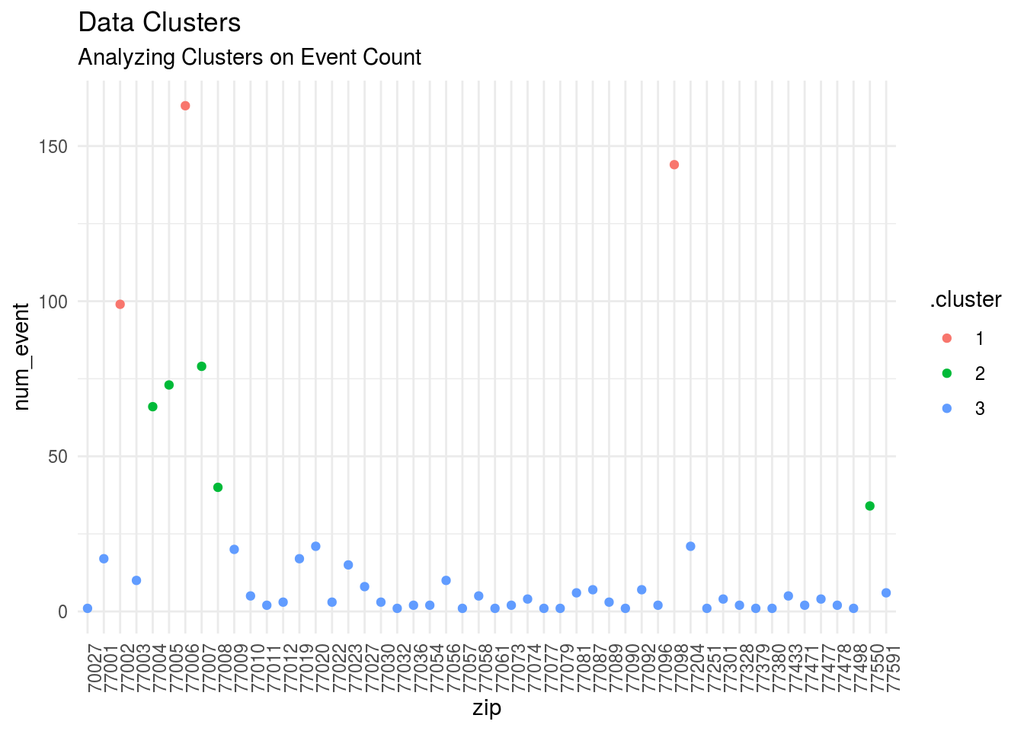

### PCA

Applying P(rincipal) C(omponent) A(nalysis) to data to extract most data characteristics without losing too much information.

It seems the first two component explains most of the variance, that is, characterize the data sufficiently.

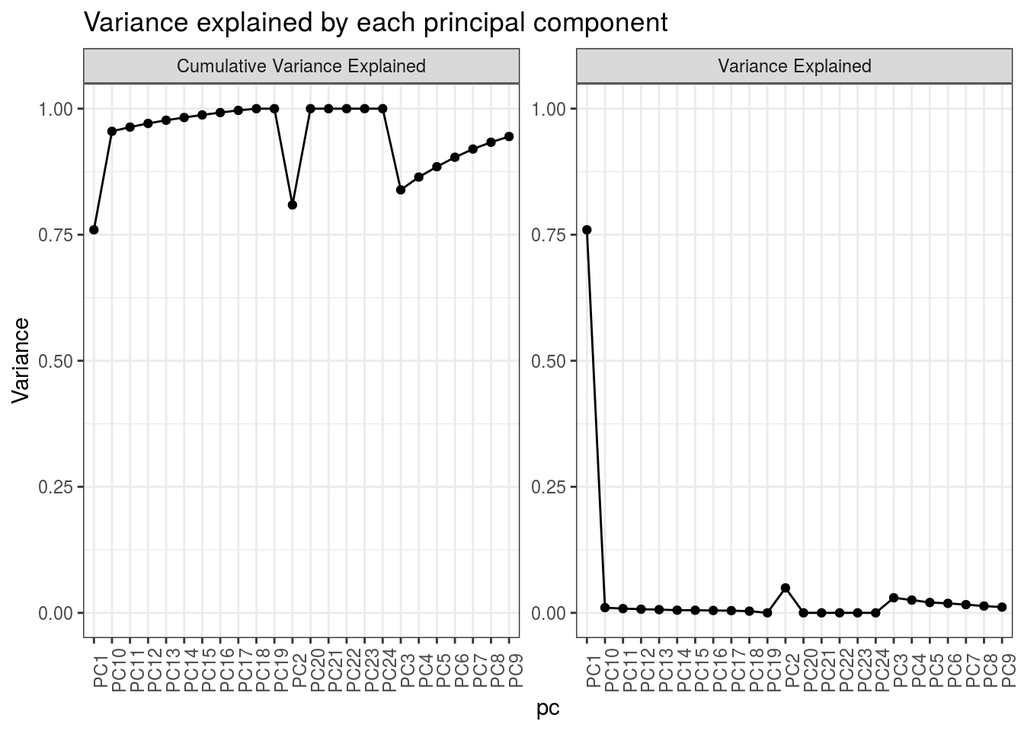

From a scatterplot of the first 2 components, 2 obvious clusters are seen.

This insight may be used to increase collaboration among event hosts to improve attendance and logistics.

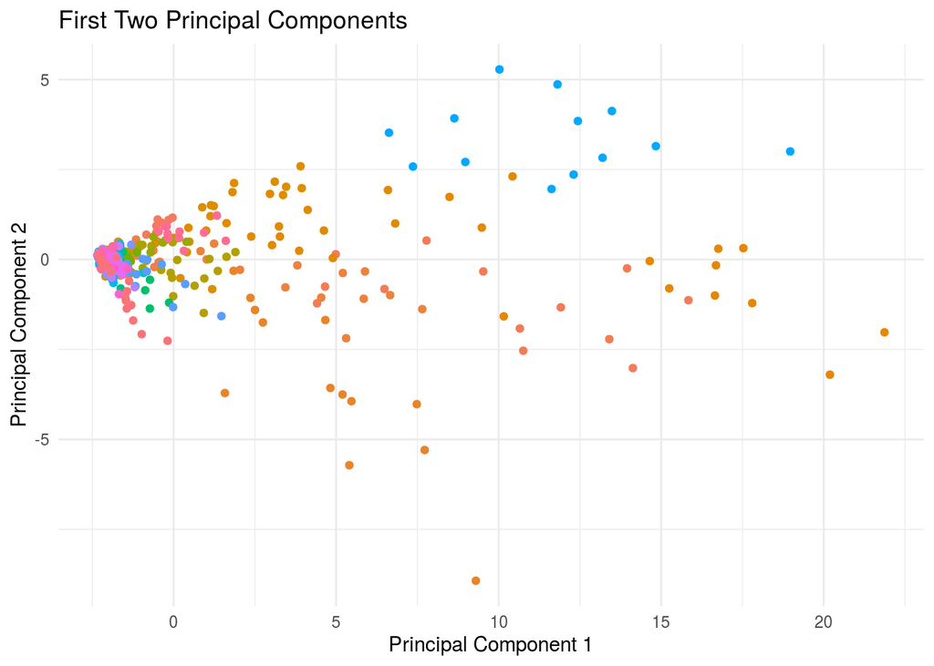